# FoS_HW_03_Group_II

anon

2025-11-05

## Part I

### 1.

#### a)

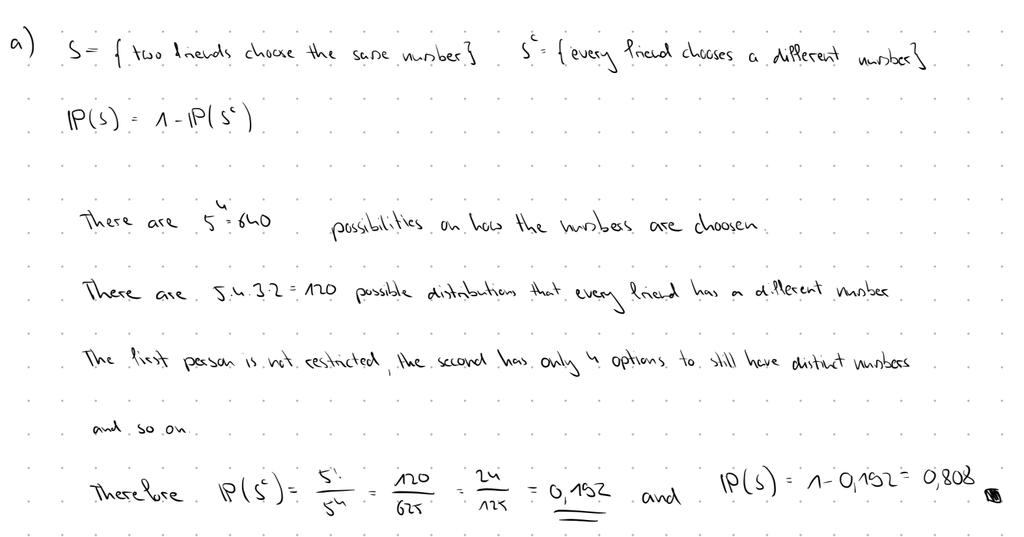

#### b)

```r
set.seed(420)
n <- 1000
count <- 0

for (i in 1:n) {
  picks <- sample(1:5, 4, replace = TRUE)
  if (length(unique(picks)) < 4) count <- count + 1
}

estimate <- count / n
print(estimate)
```

```
## [1] 0.824
```

### 2.

**Possible family compositions:**

- $P(first \quad boy)=0.5$
- $P(first \quad girl)=0.5$
- $P(girl \cap boy) = 0.5 \cdot 0.5 = 0.25$
- $P(girl \cap girl) = 0.25$

**Having;**

- $P(boy) = P(first \quad boy \cup girl \cap boy) = 0.5 + 0.25 = 0.75$
- $P(girl) = P(first \quad girl \cup girl \cap girl) = 0.5 + 0.25 = 0.75$

**Ratio**

is 1:1

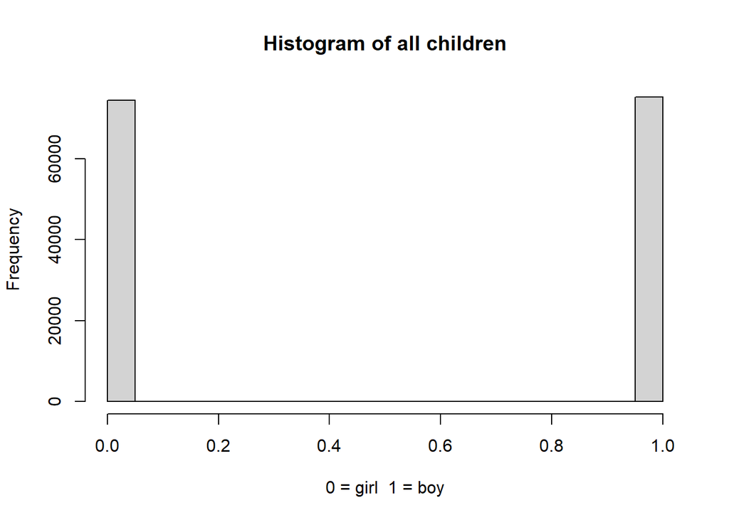

```r
sim <- function() {
  first_child <- sample(c(1, 0), 1, prob = c(0.5,0.5))  # 1=boy

  if (first_child == 1) {
    return(1)
  } else {
    second_child <- sample(c(1, 0), 1, prob = c(0.5,0.5))
    return(c(0, second_child))
  }
}

allc <- c()
for (i in 1:100000) {
  allc <- c(allc, sim())
}

hist(allc, main = "Histogram of all children", xlab = "0 = girl  1 = boy")
```

#### % of boys is;

```r
sum(allc)/length(allc)
```

```
## [1] 0.502364
```

## Part II

### 3.

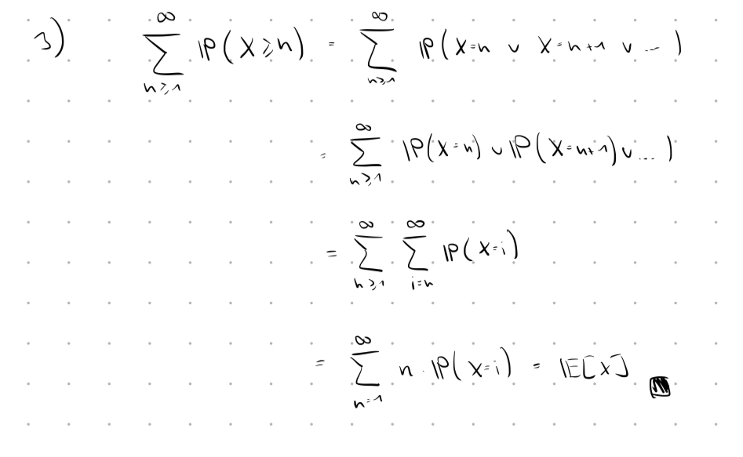

### 4.

#### a)

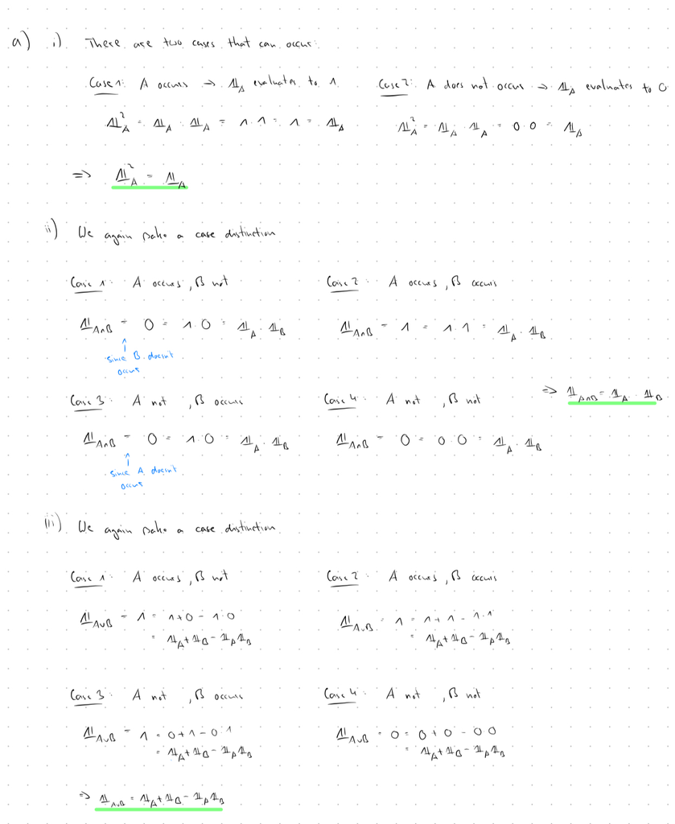

#### b), c), d)

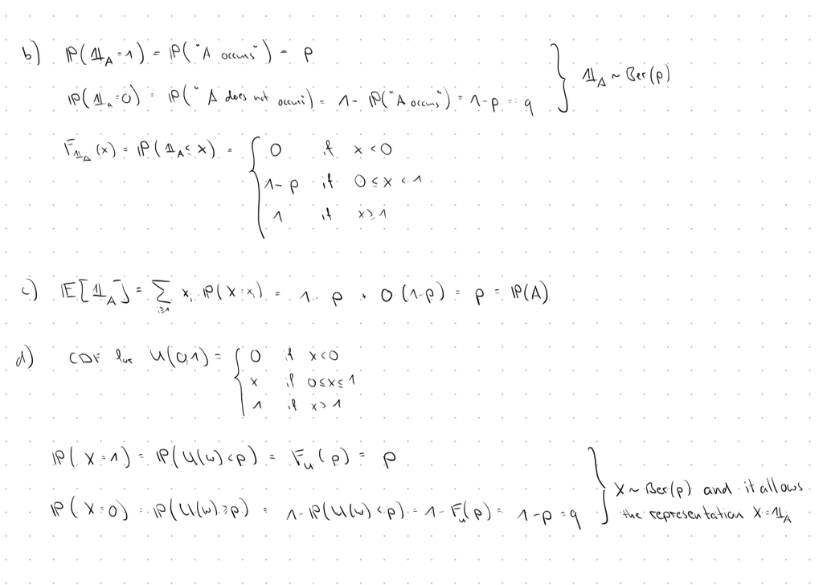

### 5.

#### a)

**Find:** The CDF of $Y = X^+ = max(0, X)$

**Case 1: $y < 0$**

Since $Y = max(0, X) \geq 0$ $\forall x$, we have $P(Y \leq y) = 0$ for $y < 0$.

**Case 2: $y \geq 0$**

For $y \geq 0$:

- $Y \leq y \iff max(0, X) \leq y$
- This is equivalent to $X \leq y$ (since both $X \leq 0$ and $0 < X \leq y$ satisfy the condition)
- Therefore: $P(Y \leq y) = P(X \leq y) = F_X(y)$

**Result:**

$$F_Y(y) = \begin{cases}
0 & \text{if } y < 0 \\
F_X(y) & \text{if } y \geq 0
\end{cases}$$

#### b)

**Find:** The CDF and PDF of Y = -X

##### CDF of Y:

$$F_Y(y) = P(Y \leq y) = P(-X \leq
y)|\cdot -1$$

$$P(-X \leq y) = P(X \geq -y)$$

$$P(X \geq -y) = 1 - P(X <
-y)$$

Since X is continuous,

$$P(X < -y) = P(X \leq -y) =
F_X(-y)$$

$$F_Y(y) = 1 - F_X(-y)$$

##### PDF of Y:

We obtain the PDF by differentiating the CDF with respect to y:

$$f_Y(y) = \frac{d}{dy} F_Y(y) =
\frac{d}{dy} [1 - F_X(-y)]$$

Using the chain rule:

$$f_Y(y) = -F_X'(-y) \cdot (-1) =
F_X'(-y) = f_X(-y)$$

### 6.

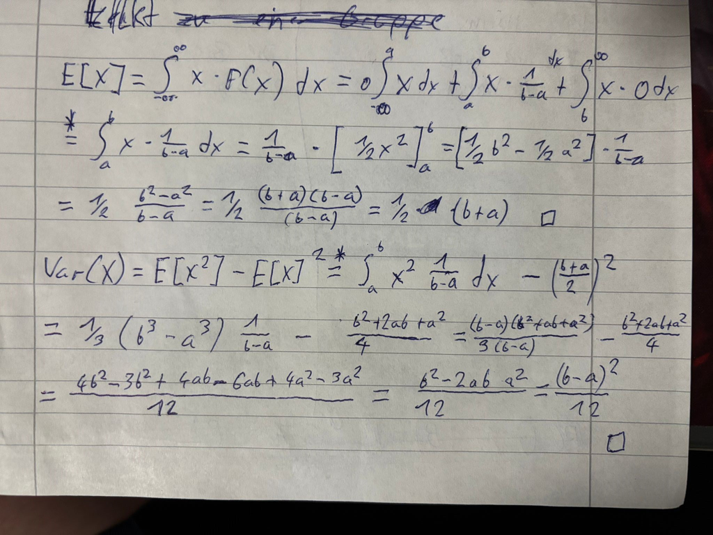

## Part III

### 7.

#### a and b)

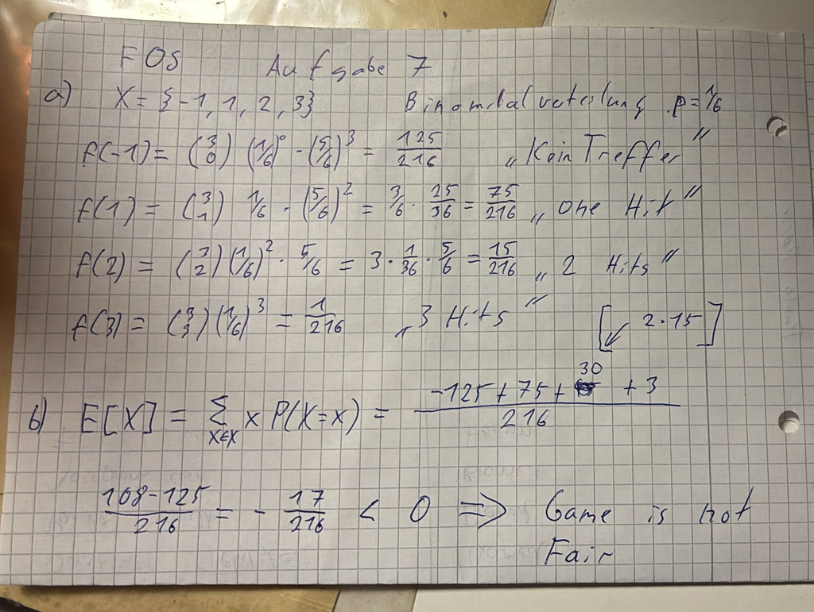

#### c)

**10000 rounds**

```r
nloop<-10000
a<-5
Win<-rep(NA,nloop)
for (k in 1:nloop){
Dice<-sample(1:6,size=3,replace=TRUE)
Count_a<-sum(Dice==a)
Win[k]<-ifelse(Count_a==0,-1,Count_a)
}
sum(Win) ## overall
```

```
## [1] -636
```

```r
avg <- sum(Win)/nloop ## on average per game
cat("For 10000 rounds we get an average profit of", avg, "compared to the theoretical value of", -17/216)
```

```
## For 10000 rounds we get an average profit of -0.0636 compared to the theoretical value of -0.0787037
```

**100000 rounds**

```r
nloop<-100000
a<-5
Win<-rep(NA,nloop)
for (k in 1:nloop){
Dice<-sample(1:6,size=3,replace=TRUE)
Count_a<-sum(Dice==a)
Win[k]<-ifelse(Count_a==0,-1,Count_a)
}
sum(Win) ## overall
```

```
## [1] -7778
```

```r
avg <- sum(Win)/nloop ## on average per game
cat("For 100000 rounds we get an average profit of", avg, "compared to the theoretical value of", -17/216)
```

```
## For 100000 rounds we get an average profit of -0.07778 compared to the theoretical value of -0.0787037
```

#### d)

Code given:

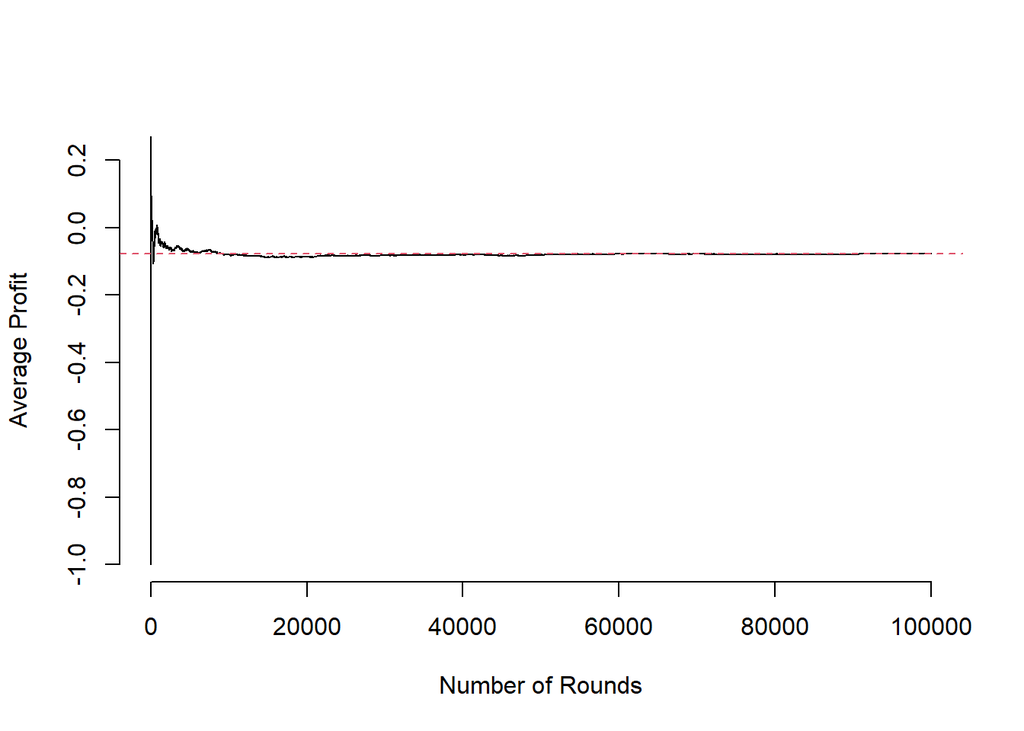

```r
options(scipen=999)
plot(cumsum(Win)/(1:nloop),type="l",bty="n",
ylab="Average Profit",xlab="Number of Rounds")
abline(h=-17/216,col=2,lty=2)
```

Our Code:

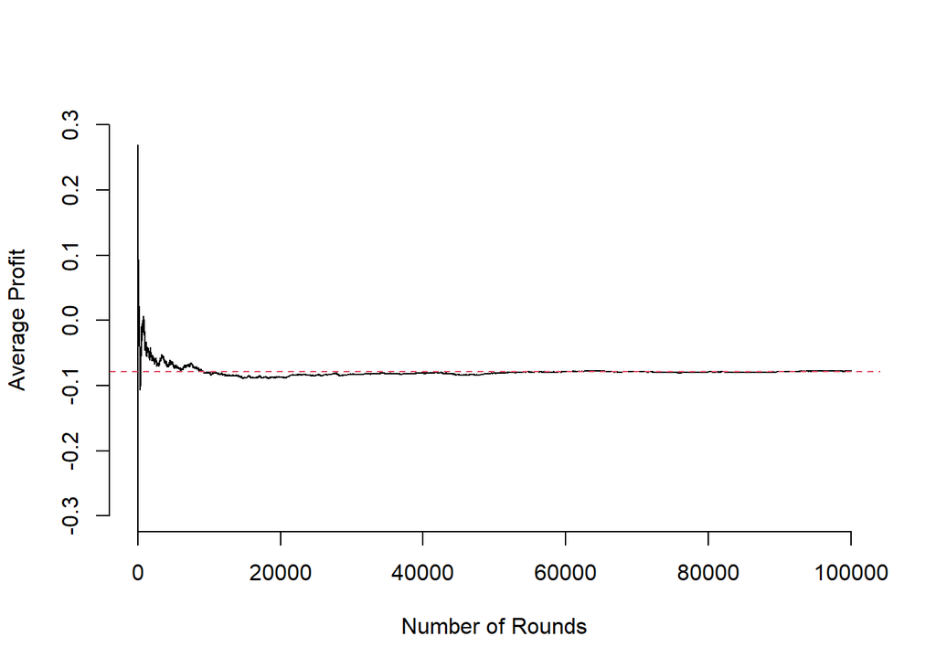

```r
options(scipen=999)
plot(cumsum(Win)/(1:nloop),type="l",bty="n",
     ylab="Average Profit",xlab="Number of Rounds",
     ylim = c(-0.3, 0.3))
abline(h=-17/216,col=2,lty=2)
```

###### I changed the y axis so that it only goes from -0.3 to 0.3 because really quick it got around the expactation and this way we see the process in more detail.

From the plot, it is evident that the average profit converges to the theoretical expected value (keyword: law of large numbers).